# Predictive Policing: Risk Modeling Minor Cannabis Possessions in Chicago, IL

Jack Rummler

2022-10-21

# 1 Introduction

Despite the consumption rate of cannabis being consistent across race, Black people are arrested at four times the rate in which white people are arrested for violating marijuana possession laws. This is consistent across the U.S. According to data from Legal Aid, people of color made up 94 percent of marijuana-related arrests. From the Wisconsin District Attorney’s Office, Black Wisconsinites were 4.3 times more likely to be arrested than any other race. This problem is even more evident in Illinois, which ranks third among all states for racial disparity in cannabis possession arrests. Prior to legalization, Black Chicagoans were 15 times more likely to get arrested for marijuana possession. Thus it is evident that cannabis possession has selection bias - particularly toward Black and other communities of color. This markdown will create a predictive policing model toward risk prediction of cannabis possession charges.

```r
policeDistricts <-
  st_read("https://data.cityofchicago.org/api/geospatial/fthy-xz3r?method=export&format=GeoJSON") %>%
  st_transform('ESRI:102271') %>%
  dplyr::select(District = dist_num)

policeBeats <-
  st_read("https://data.cityofchicago.org/api/geospatial/aerh-rz74?method=export&format=GeoJSON") %>%
  st_transform('ESRI:102271') %>%
  dplyr::select(District = beat_num)

bothPoliceUnits <- rbind(mutate(policeDistricts, Legend = "Police Districts"),
                         mutate(policeBeats, Legend = "Police Beats"))

cannabis <-
  read.socrata("https://data.cityofchicago.org/Public-Safety/Crimes-2017/d62x-nvdr") %>%
    filter(Primary.Type == "NARCOTICS" & Description == "POSS: CANNABIS 30GMS OR LESS") %>%
    mutate(x = gsub("[()]", "", Location)) %>%
    separate(x,into= c("Y","X"), sep=",") %>%
    mutate(X = as.numeric(X),Y = as.numeric(Y)) %>%
    na.omit() %>%
    st_as_sf(coords = c("X", "Y"), crs = 4326, agr = "constant")%>%
    st_transform('ESRI:102271') %>%
    distinct()

chicagoBoundary <-
  st_read(file.path(root.dir,"/Chapter5/chicagoBoundary.geojson")) %>%
  st_transform('ESRI:102271')
```

# 2 Minor Cannabis Possession Charges

In the year 2017, there were 1,211 observations of minor cannabis possessions across Chicago. There is quite evident clustering in the central-west part of the city, as well as an increased density of points further south. The south side of Chicago historically has a dense population of Black residents, which could indicate some degree of selection bias in policing.

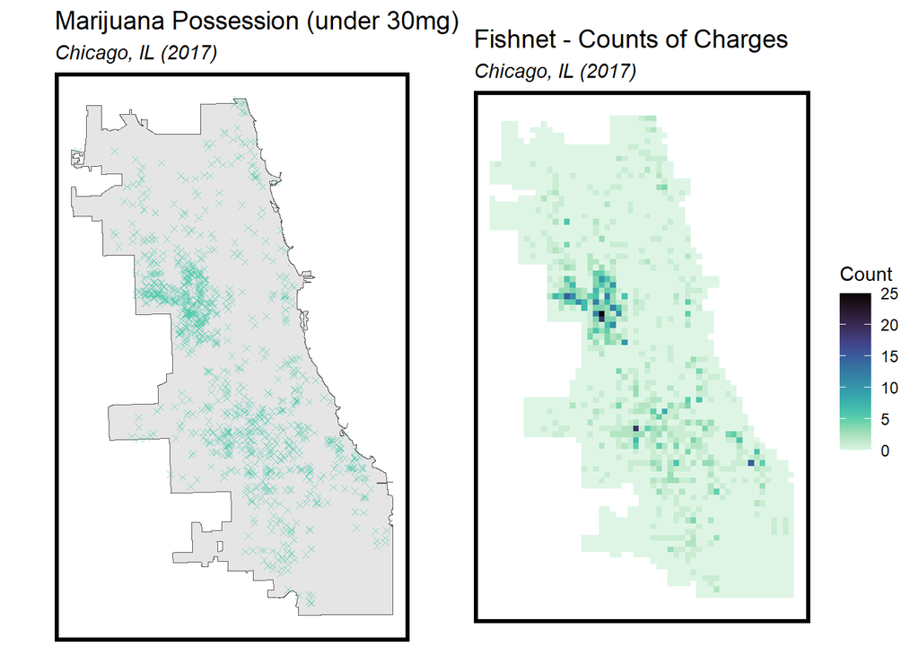

```r
fishnet <-
  st_make_grid(chicagoBoundary,
               cellsize = 500,
               square = TRUE) %>%
  .[chicagoBoundary] %>%
  st_sf() %>%
  mutate(uniqueID = 1:n())

crime_net <-
  dplyr::select(cannabis) %>%
  mutate(count.cannabis = 1) %>%
  aggregate(., fishnet, sum) %>%
  mutate(count.cannabis = replace_na(count.cannabis, 0),
         uniqueID = 1:n(),
         cvID = sample(round(nrow(fishnet) / 24),
                       size=nrow(fishnet), replace = TRUE))

grid.arrange(ncol=2,
ggplot()+
  geom_sf(data = chicagoBoundary) +
  geom_sf(data = cannabis, colour='#55CAAD', size=1.5, alpha=0.7, shape=4, show.legend = "point") +
  labs(title= "Marijuana Possession (under 30mg)", subtitle= "Chicago, IL (2017)") +
  mapTheme(),
ggplot() +
  geom_sf(data = crime_net, aes(fill = count.cannabis), color = NA) +
  scale_fill_viridis(option='G', direction=-1, name="Count") +
  labs(title = "Fishnet - Counts of Charges", subtitle= "Chicago, IL (2017)") +
  mapTheme())
```

# 3 Feature Engineering

The features I added were schools with unsafe rankings, 311 requests of abandoned buildings, graffiti, and street light outages, and cannabis delivery charges. I also did the three nearest neighbors on all of these features. Some of the biggest takeaways are the mirrored clusters of cannabis delivery charges in comparison to the cannabis possession charges, similar clusters of unsafe schools, as well as abandoned buildings. These predictably will be significant to a generalizable and accurate model.

Something to note is the racial bias that exists in 311 data which could lead to inequitable outcomes in the model. Moreover, these indicators are not meant to prove causality among built environment features and cannabis possession charges, but rather if they correlate to the spatial patterns of cannabis possession charges. Given spatial trends in 311 data, it could indicate a correlation to over-policing in certain neighborhoods of Chicago.

```r
veryweakSchools <-
  st_read("https://data.cityofchicago.org/resource/9xs2-f89t.geojson") %>%
  filter(safety_icon_ == "Very Weak" & elementary_or_high_school == "ES")

weakSchools <-
  st_read("https://data.cityofchicago.org/resource/9xs2-f89t.geojson") %>%
  filter(safety_icon_ == "Weak" & elementary_or_high_school == "ES")

schools <-
  rbind(veryweakSchools, weakSchools)

unsafe_schools <- schools %>%
  dplyr::select(geometry) %>%
  st_as_sf(coords = c("X", "Y"), crs = 4326, agr = "constant") %>%
  st_transform(st_crs(fishnet)) %>%
  mutate(Legend = "Unsafe_Schools")

abandonBuildings <-
  read.socrata("https://data.cityofchicago.org/Service-Requests/311-Service-Requests-Vacant-and-Abandoned-Building/7nii-7srd") %>%
    mutate(year = substr(date_service_request_was_received,1,4)) %>%  filter(year == "2017") %>%
    dplyr::select(Y = latitude, X = longitude) %>%
    na.omit() %>%
    st_as_sf(coords = c("X", "Y"), crs = 4326, agr = "constant") %>%
    st_transform(st_crs(fishnet)) %>%
    mutate(Legend = "Abandoned_Buildings")

graffiti <-
  read.socrata("https://data.cityofchicago.org/Service-Requests/311-Service-Requests-Graffiti-Removal-Historical/hec5-y4x5") %>%
    mutate(year = substr(creation_date,1,4)) %>% filter(year == "2017") %>%
    filter(where_is_the_graffiti_located_ %in% c("Front", "Rear", "Side")) %>%
    dplyr::select(Y = latitude, X = longitude) %>%
    na.omit() %>%
    st_as_sf(coords = c("X", "Y"), crs = 4326, agr = "constant") %>%
    st_transform(st_crs(fishnet)) %>%
    mutate(Legend = "Graffiti")

streetLightsOut <-
  read.socrata("https://data.cityofchicago.org/Service-Requests/311-Service-Requests-Street-Lights-All-Out/zuxi-7xem") %>%
    mutate(year = substr(creation_date,1,4)) %>% filter(year == "2017") %>%
    dplyr::select(Y = latitude, X = longitude) %>%
    na.omit() %>%
    st_as_sf(coords = c("X", "Y"), crs = 4326, agr = "constant") %>%
    st_transform(st_crs(fishnet)) %>%
    mutate(Legend = "Street_Lights_Out")

cannabis_del <-
  read.socrata("https://data.cityofchicago.org/Public-Safety/Crimes-2017/d62x-nvdr") %>%
    filter(Primary.Type == "NARCOTICS" & Description == "MANU/DEL:CANNABIS OVER 10 GMS") %>%
    dplyr::select(Y = Latitude, X = Longitude) %>%
    na.omit() %>%
    st_as_sf(coords = c("X", "Y"), crs = 4326, agr = "constant")%>%
    st_transform(st_crs(fishnet)) %>%
    mutate(Legend="Cannabis_Delivery")

neighborhoods <-
  st_read("https://raw.githubusercontent.com/blackmad/neighborhoods/master/chicago.geojson") %>%
  st_transform(st_crs(fishnet))

vars_net <-
  rbind(cannabis_del, streetLightsOut, abandonBuildings, unsafe_schools, graffiti) %>%
  st_join(., fishnet, join=st_within) %>%
  st_drop_geometry() %>%
  group_by(uniqueID, Legend) %>%
  summarize(count = n()) %>%
    full_join(fishnet) %>%
    spread(Legend, count, fill=0) %>%
    st_sf() %>%
    dplyr::select(-`<NA>`) %>%
    na.omit() %>%
    ungroup()

st_c <- st_coordinates
st_coid <- st_centroid

vars_net <-
  vars_net %>%
    mutate(
      Abandoned_Buildings.nn =
        nn_function(st_c(st_coid(vars_net)), st_c(abandonBuildings),3),
      Cannabis_Delivery.nn =
        nn_function(st_c(st_coid(vars_net)), st_c(cannabis_del),3),
      Graffiti.nn =
        nn_function(st_c(st_coid(vars_net)), st_c(graffiti),3),
      Street_Lights_Out.nn =
        nn_function(st_c(st_coid(vars_net)), st_c(streetLightsOut),3),
      Unsafe_Schools.nn =
        nn_function(st_c(st_coid(vars_net)), st_c(unsafe_schools),3))
```

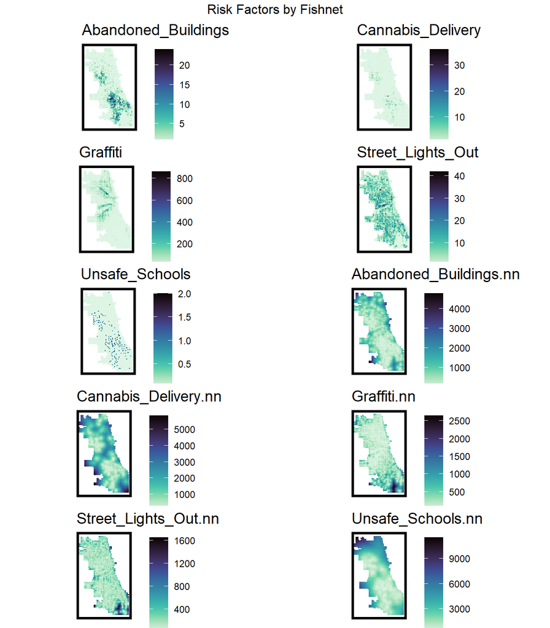

```r
vars_net.long <-
  gather(vars_net, Variable, value, -geometry, -uniqueID)

vars <- unique(vars_net.long$Variable)
mapList <- list()

for(i in vars){
  mapList[[i]] <-
    ggplot() +
      geom_sf(data = filter(vars_net.long, Variable == i), aes(fill=value), colour=NA) +
      scale_fill_viridis(option="G", direction=-1, name="") +
      labs(title=i) +
      mapTheme()}

do.call(grid.arrange,c(mapList, ncol=2, top="Risk Factors by Fishnet"))
```

```r
final_net <-
  left_join(crime_net, st_drop_geometry(vars_net), by="uniqueID")

final_net <-
  st_centroid(final_net) %>%
    st_join(dplyr::select(neighborhoods, name), by = "uniqueID") %>%
    st_join(dplyr::select(policeDistricts, District), by = "uniqueID") %>%
      st_drop_geometry() %>%
      left_join(dplyr::select(final_net, geometry, uniqueID)) %>%
      st_sf() %>%
  na.omit()
```

# 4 Local Moran’s I Indicators

Four Local Moran’s I indicators are plotted below.

Cannabis_Count: We saw this map above; it is the count of cannabis possession charges per each fishnet grid cell.

Local_Morans_I: A generalizable model must predict as well in cold spots as hot spots. It appears that the model may be underfitting to the cold spots given the higher Local Moran’s I in the significant hot spots.

P_Value: The probability of observing a particular spatial pattern in the data by chance. Given the spatial clustering of higher charge counts, lower p-values tend to be found in the hotspots, whereas we see higher p-values in lower charge counts where the spatial distribution is more random.

Significant_Hotspots: Significant spatial clusters of high cannabis count charges.

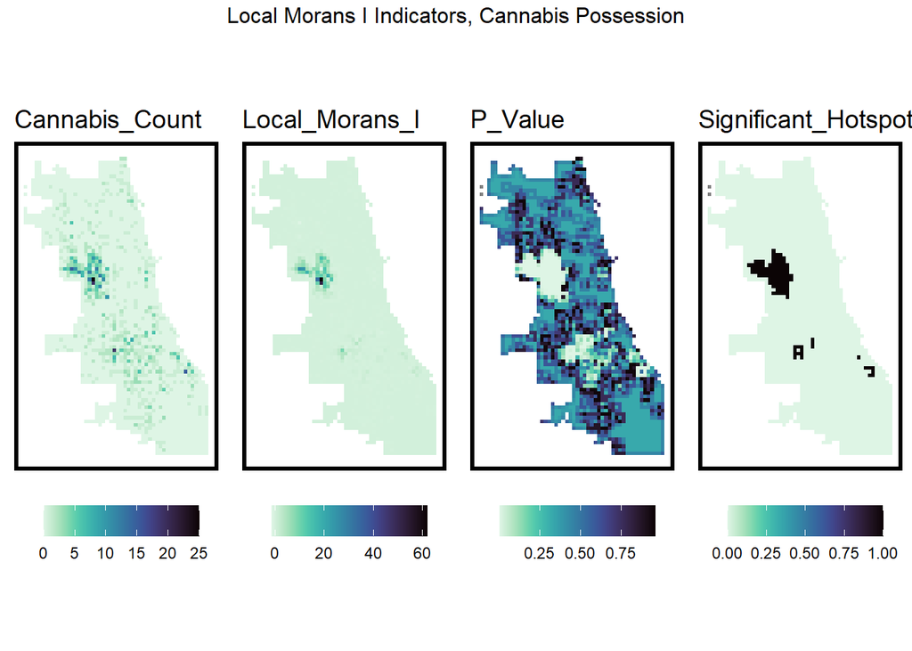

```r
final_net.nb <- poly2nb(as_Spatial(final_net), queen=TRUE)
final_net.weights <- nb2listw(final_net.nb, style="W", zero.policy=TRUE)

local_morans <- localmoran(final_net$count.cannabis, final_net.weights, zero.policy=TRUE) %>%
  as.data.frame()

final_net.localMorans <-
  cbind(local_morans, as.data.frame(final_net)) %>%
  st_sf() %>%
  dplyr::select(Cannabis_Count = count.cannabis,
                Local_Morans_I = Ii,
                P_Value = `Pr(z != E(Ii))`) %>%
  mutate(Significant_Hotspots = ifelse(P_Value <= 0.001, 1, 0)) %>%
  gather(Variable, Value, -geometry)

vars <- unique(final_net.localMorans$Variable)
varList <- list()

for(i in vars){
  varList[[i]] <-
    ggplot() +
      geom_sf(data = filter(final_net.localMorans, Variable == i),
              aes(fill = Value), colour=NA) +
      scale_fill_viridis(option="G", direction=-1) +
      labs(fill="", title=i) +
      mapTheme()+
    theme(legend.position="bottom")}

do.call(grid.arrange,c(varList, ncol = 4, top = "Local Morans I Indicators, Cannabis Possession"))
```

# 5 Correlations

Most of the scatterplots indicate relatively weak relationships with count of cannabis per fishnet cell. Cannabis delivery seems to have the strongest overall relationship, indicating quite a positive correlation. Graffiti and graffiti KNN have very weak relationships.

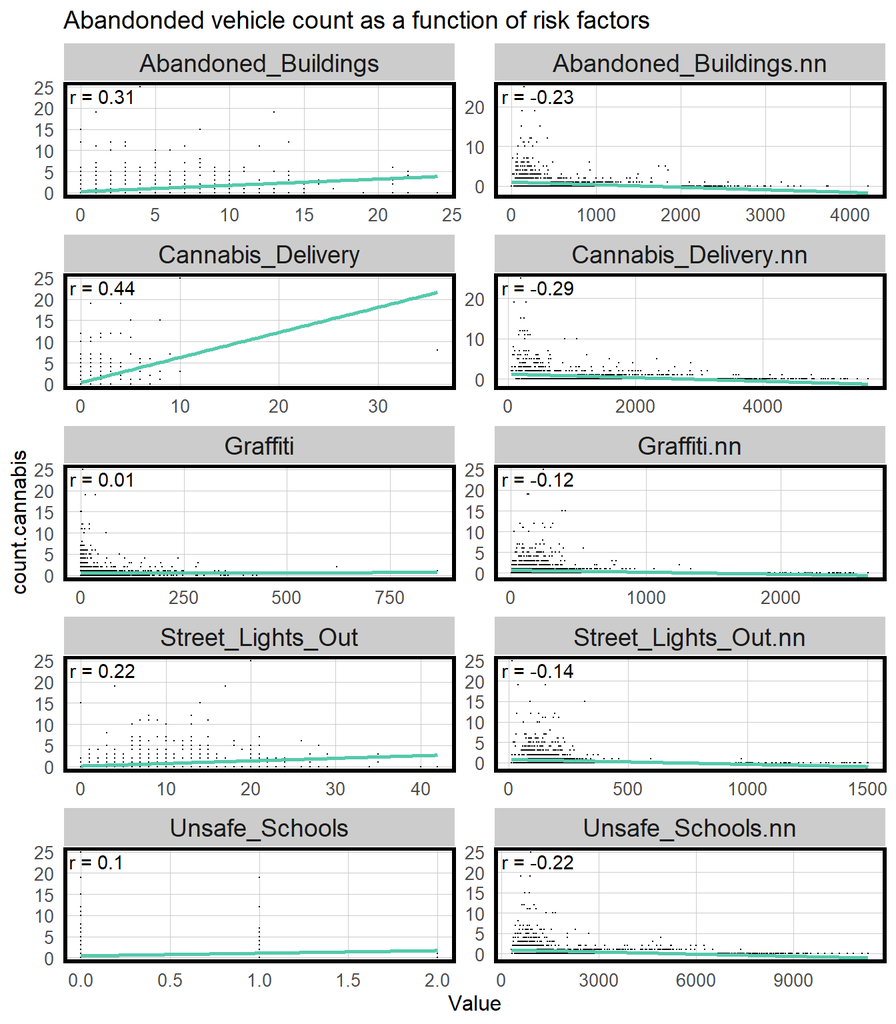

```r
correlation.long <-
  st_drop_geometry(final_net) %>%
  dplyr::select(-uniqueID, -District, -name, -cvID) %>%
  gather(Variable, Value, -count.cannabis)

correlation.cor <-
  correlation.long %>%
  group_by(Variable) %>%
  summarize(correlation = cor(Value, count.cannabis, use = "complete.obs"))

ggplot(correlation.long, aes(Value, count.cannabis)) +
  geom_point(size = 0.1) +
  geom_text(data = correlation.cor, aes(label = paste("r =", round(correlation, 2))),
            x=-Inf, y=Inf, vjust = 1.5, hjust = -.1) +
  geom_smooth(method = "lm", se = FALSE, colour = "#55CAAD") +
  facet_wrap(~Variable, ncol = 2, scales = "free") +
  labs(title = "Abandonded vehicle count as a function of risk factors") +
  plotTheme()
```

```r
cor_net <-
  left_join(crime_net, st_drop_geometry(vars_net), by="uniqueID")
```

# 6 Histogram of Cannabis Possession

Many of the fishnet cells have zero observations. We will use a Poisson regression to understand the latent risk of cannabis possession charges.

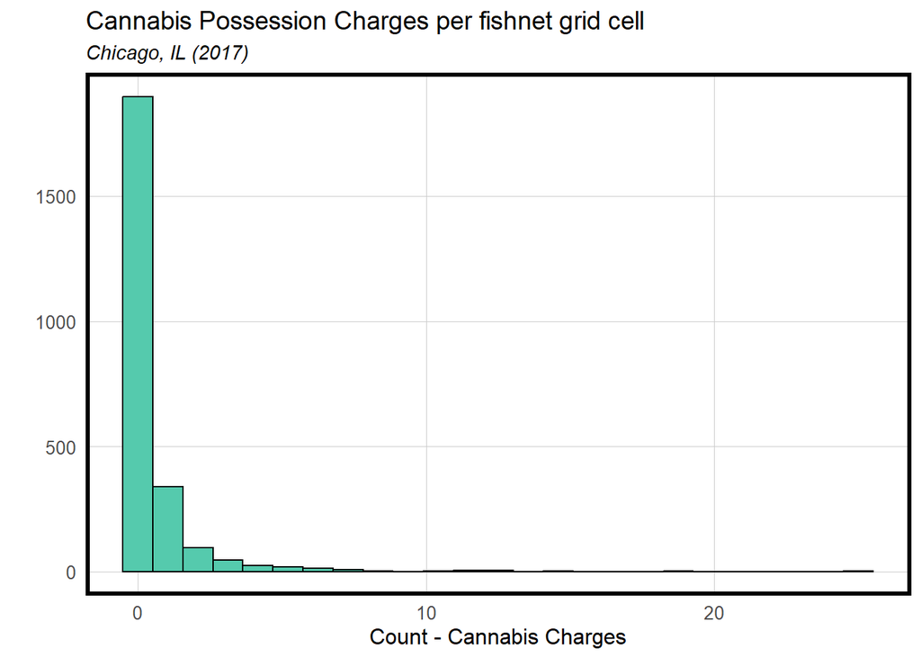

```r
ggplot(cor_net, aes(x=count.cannabis)) +
  geom_histogram(color="black", fill="#55CAAD",bins=25)+
  labs(title="Cannabis Possession Charges per fishnet grid cell", subtitle = "Chicago, IL (2017)", y = "", x ="Count - Cannabis Charges")+
  plotTheme()
```

# 7 Random k-fold and cross validation with A Poisson Regression

Because of the extremely weak relationships seen in graffiti, they were removed from the modeling. In this step, we create two different ways to cross-validate our models - spatial random k-fold and leave-one-group-out (LOGO) cross validation. In the histograms below, we see that our standard error is low, except for a few outliers in both methods, heavily skewing the data.

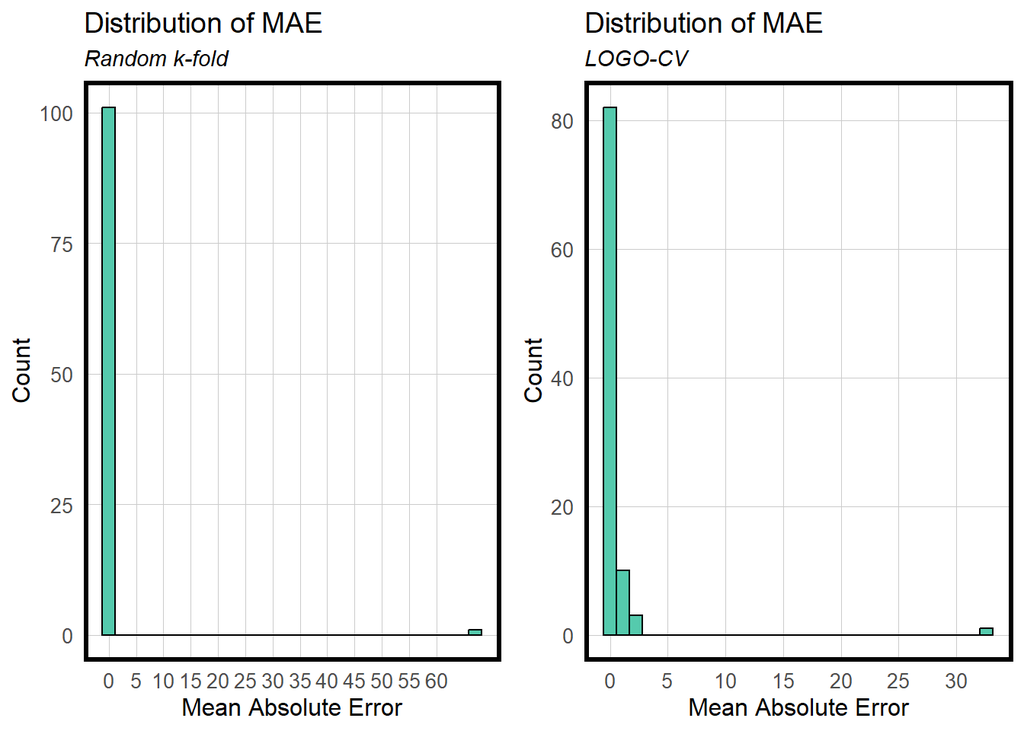

```r
reg.ss.vars <- c("Abandoned_Buildings", "Abandoned_Buildings.nn",
              "Cannabis_Delivery", "Cannabis_Delivery.nn",
              "Street_Lights_Out", "Street_Lights_Out.nn",
              "Unsafe_Schools", "Unsafe_Schools.nn")

reg.ss.spatialCV <- crossValidate(dataset = final_net,
                                  id = "name",
                                  dependentVariable = "count.cannabis",
                                  indVariables = reg.ss.vars) %>% dplyr::select(cvID = name, count.cannabis, Prediction, geometry)

reg.ss.cv <- crossValidate(dataset = final_net,
                           id = "cvID",
                           dependentVariable = "count.cannabis",
                           indVariables = reg.ss.vars) %>% dplyr::select(cvID = cvID, count.cannabis, Prediction, geometry)

reg.summary <-
  rbind(
    mutate(reg.ss.cv,        Error = Prediction - count.cannabis,
                             Regression = "Random k-fold CV: Spatial Process"),
    mutate(reg.ss.spatialCV, Error = Prediction - count.cannabis,
                             Regression = "Spatial LOGO-CV: Spatial Process")) %>%
    st_sf()

error_by_reg_and_fold <-
  reg.summary %>%
    group_by(Regression, cvID) %>%
    summarize(Mean_Error = mean(Prediction - count.cannabis, na.rm = T),
              MAE = mean(abs(Mean_Error), na.rm = T),
              SD_MAE = mean(abs(Mean_Error), na.rm = T)) %>%
  ungroup()

error_by_reg_and_fold %>%
  arrange(desc(MAE))
error_by_reg_and_fold %>%
  arrange(MAE)

reg.ss.vars <- c("Abandoned_Buildings", "Abandoned_Buildings.nn",
              "Cannabis_Delivery", "Cannabis_Delivery.nn",
              "Street_Lights_Out", "Street_Lights_Out.nn",
              "Unsafe_Schools", "Unsafe_Schools.nn")

reg.ss.spatialCV <- crossValidate(dataset = final_net,
                                  id = "name",
                                  dependentVariable = "count.cannabis",
                                  indVariables = reg.ss.vars) %>% dplyr::select(cvID = name, count.cannabis, Prediction, geometry)

reg.ss.cv <- crossValidate(dataset = final_net,
                           id = "cvID",
                           dependentVariable = "count.cannabis",
                           indVariables = reg.ss.vars) %>% dplyr::select(cvID = cvID, count.cannabis, Prediction, geometry)

reg.summary <-
  rbind(
    mutate(reg.ss.cv,        Error = Prediction - count.cannabis,
                             Regression = "Random k-fold CV: Spatial Process"),
    mutate(reg.ss.spatialCV, Error = Prediction - count.cannabis,
                             Regression = "Spatial LOGO-CV: Spatial Process")) %>%
    st_sf()

error_by_reg_and_fold <-
  reg.summary %>%
    group_by(Regression, cvID) %>%
    summarize(Mean_Error = mean(Prediction - count.cannabis, na.rm = T),
              MAE = mean(abs(Mean_Error), na.rm = T),
              SD_MAE = mean(abs(Mean_Error), na.rm = T)) %>%
  ungroup()

error_by_reg_and_fold %>%
  arrange(desc(MAE))
error_by_reg_and_fold %>%
  arrange(MAE)

reg1 <- subset(error_by_reg_and_fold, Regression == "Random k-fold CV: Spatial Process")
reg2 <- subset(error_by_reg_and_fold, Regression == "Spatial LOGO-CV: Spatial Process")

grid.arrange(ncol=2,
ggplot(data=reg1, aes(MAE)) +
  geom_histogram(bins = 30, colour="black", fill = "#55CAAD") +
  scale_x_continuous(breaks = seq(0, 60, by = 5)) +
  labs(title="Distribution of MAE", subtitle = "Random k-fold", x="Mean Absolute Error", y="Count")+
  plotTheme(),
ggplot(data=reg2, aes(MAE)) +
  geom_histogram(bins = 30, colour="black", fill = "#55CAAD") +
  scale_x_continuous(breaks = seq(0, 35, by = 5)) +
  labs(title="Distribution of MAE", subtitle = "LOGO-CV", x="Mean Absolute Error", y="Count")+
  plotTheme())
```

When we remove the outliers, we see our average error for both methods remains under 2 with a heavy zero-skew.

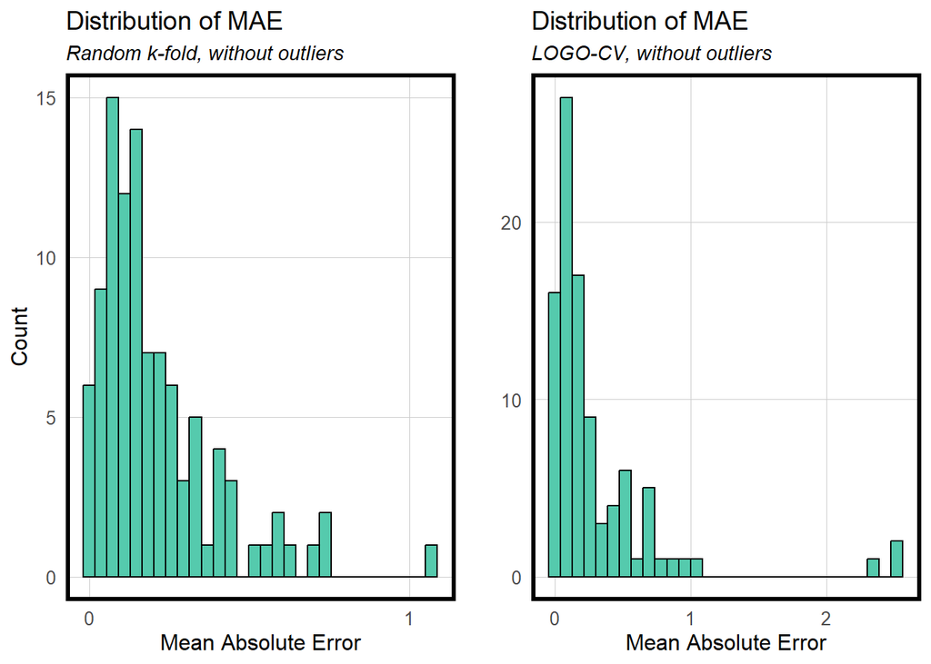

```r
reg3 <- subset(reg1, MAE < 5)
reg4 <- subset(reg2, MAE < 5)
reg5 <- rbind(reg3, reg4)

grid.arrange(ncol=2,
ggplot(data=reg3, aes(MAE)) +
  geom_histogram(bins = 30, colour="black", fill = "#55CAAD") +
  scale_x_continuous(breaks = seq(0, 5, by = 1)) +
  labs(title="Distribution of MAE", subtitle = "Random k-fold, without outliers", x="Mean Absolute Error", y="Count")+
  plotTheme(),
ggplot(data=reg4, aes(MAE)) +
  geom_histogram(bins = 30, colour="black", fill = "#55CAAD") +
  scale_x_continuous(breaks = seq(0, 5, by = 1)) +
  labs(title="Distribution of MAE", subtitle = "LOGO-CV, without outliers", x="Mean Absolute Error", y="")+
  plotTheme())
```

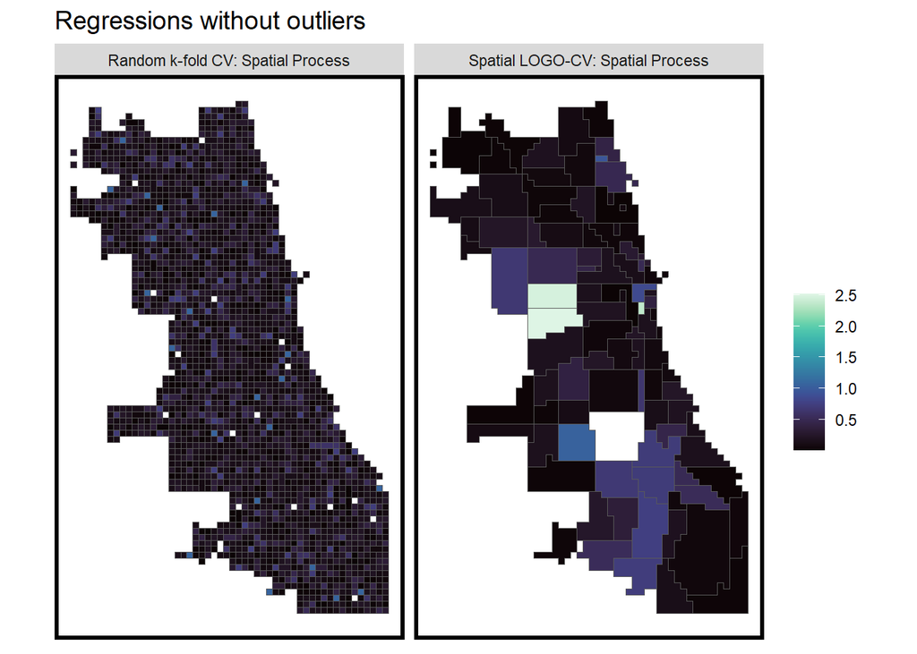

```r
ggplot() +
  geom_sf(data = reg5, aes(fill=MAE)) +
  scale_fill_viridis(option="G", name="") +
  labs(title="Regressions without outliers") +
  facet_wrap(~Regression, ncol=2)+
  mapTheme()
```

# 8 MAE and Standard Deviation of MAE

```r
st_drop_geometry(error_by_reg_and_fold) %>%
  group_by(Regression) %>%
    summarize(Mean_MAE = round(mean(MAE), 2),
              SD_MAE = round(sd(MAE), 2)) %>%
kable() %>%
  kable_styling("striped", full_width = F)
```

[output not shown]

As we can see when the outliers are removed, mean and SD MAE are significantly reduced.

```r
st_drop_geometry(reg5) %>%
  group_by(Regression) %>%
    summarize(Mean_MAE = round(mean(MAE), 2),
              SD_MAE = round(sd(MAE), 2)) %>%
kable() %>%
  kable_styling("striped", full_width = F)
```

| Regression | Mean_MAE | SD_MAE |
| --- | --- | --- |
| Random k-fold CV: Spatial Process | 0.21 | 0.19 |
| Spatial LOGO-CV: Spatial Process | 0.30 | 0.46 |

# 9 Race Context

```r
census_api_key("3c896250ea8d421462ade754e4dcecdf8f55e0f2", overwrite = TRUE)

tracts18 <-
  get_acs(geography = "tract", variables = c("B01001_001E","B01001A_001E"),
          year = 2018, state=17, county=031, geometry=T) %>%
  st_transform('ESRI:102271')  %>%
  dplyr::select(variable, estimate, GEOID) %>%
  spread(variable, estimate) %>%
  rename(TotalPop = B01001_001,
         NumberWhites = B01001A_001) %>%
  mutate(percentWhite = NumberWhites / TotalPop,
         raceContext = ifelse(percentWhite > .5, "Majority_White", "Majority_Non_White")) %>%
  .[neighborhoods,]

reg.summary %>%
  filter(str_detect(Regression, "Spatial Process")) %>%
    st_centroid() %>%
    st_join(tracts18) %>%
    na.omit() %>%
      st_drop_geometry() %>%
      group_by(Regression, raceContext) %>%
      summarize(mean.Error = mean(Error, na.rm = T)) %>%
      spread(raceContext, mean.Error) %>%
      kable(caption = "Mean Error by neighborhood racial context") %>%
        kable_styling("striped", full_width = F)
```

[output not shown]

# 10 Kernel density vs. risk prediction

When comparing business-as-usual approaches to policing over predicting latent risk of crime, we hope that our risk prediction model outperforms our kernel density model when areas are designated at increased risk. In this section, we compare the kernel density hot spot map to the risk categories defined by our model, and see if it is capable of outperforming.

```r
can_ppp <- as.ppp(st_coordinates(cannabis), W = st_bbox(final_net))
can_KD.1000 <- spatstat.core::density.ppp(can_ppp, 1000)
can_KD.1500 <- spatstat.core::density.ppp(can_ppp, 1500)
can_KD.2000 <- spatstat.core::density.ppp(can_ppp, 2000)
can_KD.df <- rbind(
  mutate(data.frame(rasterToPoints(mask(raster(can_KD.1000), as(neighborhoods, 'Spatial')))), Legend = "1000 Ft."),
  mutate(data.frame(rasterToPoints(mask(raster(can_KD.1500), as(neighborhoods, 'Spatial')))), Legend = "1500 Ft."),
  mutate(data.frame(rasterToPoints(mask(raster(can_KD.2000), as(neighborhoods, 'Spatial')))), Legend = "2000 Ft."))

can_KD.df$Legend <- factor(can_KD.df$Legend, levels = c("1000 Ft.", "1500 Ft.", "2000 Ft."))
```

```r
cannabis18 <-
  read.socrata("https://data.cityofchicago.org/Public-Safety/Crimes-2018/3i3m-jwuy") %>%
  filter(Primary.Type == "NARCOTICS" & Description == "POSS: CANNABIS 30GMS OR LESS") %>%
  mutate(x = gsub("[()]", "", Location)) %>%
  separate(x,into= c("Y","X"), sep=",") %>%
  mutate(X = as.numeric(X),
         Y = as.numeric(Y)) %>%
  na.omit %>%
  st_as_sf(coords = c("X", "Y"), crs = 4326, agr = "constant") %>%
  st_transform('ESRI:102271') %>%
  distinct() %>%
  .[fishnet,]


can_KDE_sum <- as.data.frame(can_KD.1000) %>%
  st_as_sf(coords = c("x", "y"), crs = st_crs(final_net)) %>%
  aggregate(., final_net, mean)
kde_breaks <- classIntervals(can_KDE_sum$value,
                             n = 5, "fisher")
can_KDE_sf <- can_KDE_sum %>%
  mutate(label = "Kernel Density",
         Risk_Category = classInt::findCols(kde_breaks),
         Risk_Category = case_when(
           Risk_Category == 5 ~ "5th",
           Risk_Category == 4 ~ "4th",
           Risk_Category == 3 ~ "3rd",
           Risk_Category == 2 ~ "2nd",
           Risk_Category == 1 ~ "1st")) %>%
  cbind(
    aggregate(
      dplyr::select(cannabis18) %>% mutate(canCount = 1), ., sum) %>%
    mutate(canCount = replace_na(canCount, 0))) %>%
  dplyr::select(label, Risk_Category, canCount)


ml_breaks <- classIntervals(reg.ss.spatialCV$Prediction,
                             n = 5, "fisher")
can_risk_sf <- reg.ss.spatialCV %>%
  mutate(label = "Risk Predictions",
         Risk_Category =classInt::findCols(ml_breaks),
         Risk_Category = case_when(
           Risk_Category == 5 ~ "5th",
           Risk_Category == 4 ~ "4th",
           Risk_Category == 3 ~ "3rd",
           Risk_Category == 2 ~ "2nd",
           Risk_Category == 1 ~ "1st")) %>%
  cbind(
    aggregate(
      dplyr::select(cannabis18) %>% mutate(canCount = 1), ., sum) %>%
      mutate(burgCount = replace_na(canCount, 0))) %>%
  dplyr::select(label,Risk_Category, canCount)
```

Kernel density supersedes risk prediction significantly in the highest risk category, rendering this algorithm ineffective.

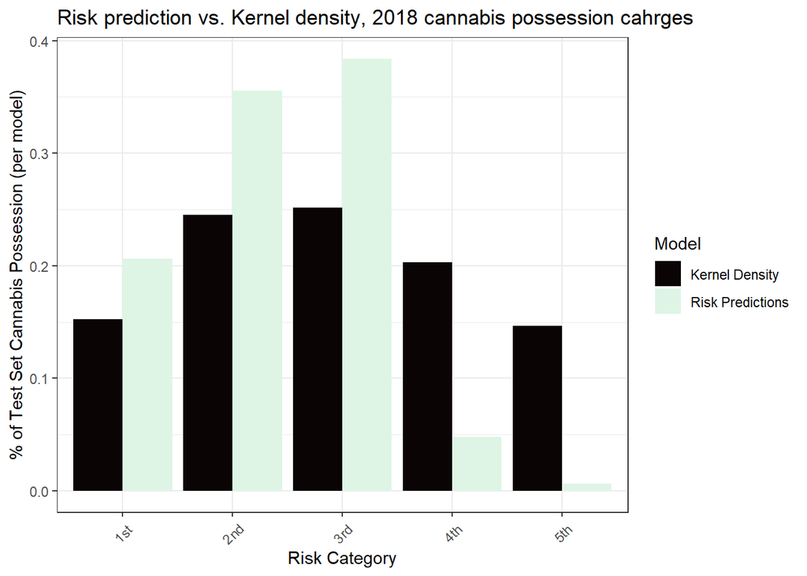

```r
rbind(can_KDE_sf, can_risk_sf) %>%
  st_drop_geometry() %>%
  na.omit() %>%
  gather(Variable, Value, -label, -Risk_Category) %>%
  group_by(label, Risk_Category) %>%
  summarize(count.cannabis = sum(Value)) %>%
  ungroup() %>%
  group_by(label) %>%
  mutate(Pcnt_of_test_set_crimes = count.cannabis/ sum(count.cannabis)) %>%
    ggplot(aes(Risk_Category,Pcnt_of_test_set_crimes)) +
      geom_bar(aes(fill=label), position="dodge", stat="identity") +
      scale_fill_viridis(option="G", discrete = TRUE, name = "Model") +
      labs(title = "Risk prediction vs. Kernel density, 2018 cannabis possession cahrges",
           y = "% of Test Set Cannabis Possession (per model)",
           x = "Risk Category") +
  theme_bw() +
      theme(axis.text.x = element_text(angle = 45, vjust = 0.5))
```

# 11 Conclusion

Unfortunately, I would not recommend this model go to production. This model needs quite a lot of work before being considered accurate and generalizable. For one, the data itself lacked a lot of spatial significance. While there was definite clustering of the data, many of the fishnet cells had zero counts, which instantly could have impacted the model. The engineered features also seemed to lack significant correlation with the cannabis counts. I would add more features that capture spatial processes to facilitate more correlation.

The average MAE was very high and definitely underfit certain neighborhoods. Once contextualized with race, it is clear that this model would still target Black neighborhoods, which creates further inequity and selection bias. Moreover, the risk prediction was extremely low for areas at highest risk, meaning this model would not be useful and does not capture the latent risk that exists in certain neighborhoods. When looking at MAE, only a few outliers were able to completely alter the mean and standard deviation of the MAE, which ultimately snowballed into an underpeforming model to areas at highest risk. Further research could help determine why these outliers existed and how we could alter our spatial process to see improved performance.

However, the foundational problem we are asking is the latent risk of cannabis possession and the spatial processes in over-policed neighborhoods. Even if an improved model can better predict for neighborhoods at higher risk, is it founded in selection biases?